#### About this document

This is the assignment for the UCL module Data Science for Spatial Systems (CASA0006)  
**Code is hosted [here](https://github.com/minghaninucl/CASA06)**  
**Data is availble [here](https://raw.githubusercontent.com/minghaninucl/CASA06/main/fuel_poverty_2015_eul.csv)**  
**Data description is availble [here](http://doc.ukdataservice.ac.uk/doc/8228/mrdoc/pdf/8228_2015_fuel_poverty_dataset_documentation.pdf)**

# Predict Fuel Poverty With Less Information

*the case of the UK in 2015*

*This paper explores the Fuel Poverty Dataset, part of the English Housing Survey,published by: Department for Business, Energy & Industrial Strategy in 2015. This document presents both an exploration analysis and an comparison of popular classification algorithms to predict whether a household is in fuel poverty.*

## 1. Introduction

Fuel poverty is publicly recognized as one of the biggest social-equity problems in Europe and US these years with severe consequences that include definition of quality of life, adverse effects on public health and inequity(Lyra, Mirasgedis and Tourkolias, 2022). Excess winter mortality rate is observed in old and damp households. Similarly, during hot summer, households that can’t afford air-conditioner can also make the most venerable suffer.

There is, however, no single definition of fuel poverty across the Europe. The UK's definition for fuel poverty is that: people who are in fuel poverty are those whose fuel costs are above average national median level but were they spend that amount, they would be left with a residual income below official poverty line ([BEIS, 2018](https://www.gov.uk/government/collections/fuel-poverty-statistics)). In France, the definition for fuel poverty is that any person who experiences specific difficulties in accessing the power supply required to satisfy their basic needs, due to inadequacy of their resources their living conditions, is in fuel poverty (Tyszler and Leseur, 2013).

Generally, fuel poverty results from a mixture of three factors: low income, higher energy prices and inadequate household energy requirements ([BEIS, 2018](https://www.gov.uk/government/collections/fuel-poverty-statistics)). More recently, fuel poverty is considered as a multidimensional social problem and therefore is also related to household composition, dwelling type, household demography, health status of its residents and employment status, etc. (Mashhoodi et al.,2019). Moreover, Mashhoodi et al. (2019) suggests that geographical factor can impact the levels of fuel poverty.

This study adopts Hills.(2011) definition of fuel poverty' to explore the fuel poverty dataset in 2015 of the UK published by Department for Business, Energy & Industrial Strategy. According to the definition, 4 types of households can be identified: 1) households with high income and low fuel costs (HILC), 2) households with high income and high fuel costs (HIHC), 3) households with low income and low fuel costs (LILC) and 4) households with low income and high fuel costs (LIHC). Only LIHC households are regarded as households in fuel poverty. The dataset has labeled household into only two types, i.e. households in fuel poverty and households not in fuel poverty.

But under actual circumstances, it's difficult to get the accurate infomation about household income and fuel costs. Collecting such data by energy companies may also violate the **General Data Protection Regulation (GDRR)**. Additionally, people also regard this information as privacy and are sometimes reluctant to offer.

To solve the paradox, popular classification algorithms are tested using dataset that removes fuel costs (`fuel_costs`), household income('hh_income') and household costs( `HousingCosts`). By doing so, we want to test if only using the basic information such as incomde deciles, geographic information, EPC rating, household demographic, and dwelling characteristic we can still have a reseasonable prediction of fuel poverty. The algorithms tested include Logistic Regression, Decision Tree, Random Forest, Multi-layer Perceptron (MLP) classifier, and Adaboost Classifier.

The study tries to answer the following questions:

`Q1. Which classification method have the best performance for fuel poverty prediction?`

`Q2. Which fatcors are most related to fuel poverty?`

### 1.1 | Requirements to run the analysis

An overview of packages used to run the analysis with brief explanation of their role.

```python
# Packages for data manipulation and processing
import math
import numpy as np
import pandas as pd
pd.set_option('display.max_rows', 100)
import requests as requests
import datetime

# Packages for visualisation
from matplotlib import pyplot as plt # primary plotting package
import matplotlib.ticker as ticker # plt ticker manipulation
import seaborn as sns; sns.set(style="ticks", color_codes=True) # for specialised pairplot visuals
from matplotlib import pyplot

# for inbalanced dataset
# pip install imblearn
from imblearn.ensemble import EasyEnsembleClassifier

## classifiers
from sklearn.neural_network import MLPClassifier
from sklearn.tree import DecisionTreeClassifier
from sklearn.ensemble import AdaBoostClassifier
from sklearn.ensemble import RandomForestClassifier
from sklearn.linear_model import LogisticRegression

# metrics
from sklearn import metrics

# testing importance of features
from sklearn.feature_selection import SelectKBest
from sklearn.feature_selection import chi2

# Notebook settings
random_state = 123 # for reproducability
np.random.seed(random_state) # setting numpy random seed, as that is used for sklearn operations
```

## 2.Literature review

**Literature**  
According to Fazanie and Kahouli.(2019), the methods to measuring fuel poverty can be categorized into 3 general groups: (a) objective approaches is based on the proportion of household income required to keep the living space comfortable, (b) subjective evalution based on the level of avalible energy equipments or appliances, and composite indicators that considering multiple factors such as household characteristics, employment status, health conditions of residents, etc.

Households in fuel poverty are mainly associated with low income and high energy expenditures. Therefore, these two factors are furthur related to high energy prices, poor housing, inefficient heating or cooling equipments, geographic factors, number and age structure of residents, and emloyment status.

2 Logistic regression models have been employed to link fuel poverty to sevral of the above-mentioned factors in a study of fuel poverty of Greece(Lyra, Mirasgedis and Tourkolias, 2022). They suggests that types of dwelling, location of households, education level of main bread-earner of the housesholds are the main factors contributes to fuel poverty in Greece.

## 3.0 | Methodology

**Data characteristics**  
There are 4 types of **Independent Variables** in our dataset, including **expenditure variables, energy efficiency variables, and dwelling characteristics variables, household characteritics variables**. The expenditure variables include household income, toatl energy costs,housing costs; the energy efficiency variables include EPC rating, central heating or not, main fuel type, wall type, insulation thickness, boiler or not; the dwelling characteristics variables includes Region, Tenure, dwelling types, age of dwelling, floor area; household characteritics variables include houshold composition, working status, ethnic origin, household size, and number of residents in sick.

**Method**  
**Supervised learning** is one of the two branches of machine learning that enables the model to predict future outcomes after being trained with past data as input. Supervised learning models can be further classied into **regression** and **classification** according to the type of output. The outputs of **regression model** are continuous while the outputs are categorical for **classification**(Chandra Sen, Hajra and Ghosh, 2020). In our case, there are only two outputs of fuel poverty, namely, in fuel poverty and not in fuel poverty. Therefore, it's a classification problem.

**Popular Classification algorithms** include Logistic regression, decision regression, random forest, Adaboost, in which logistic regression is often used to predict binary outcomes.

**Resampling**  
Most of the households are not in fuel poverty, so the dataset is imbalanced. In this case, both upsampling and downsampling techniques are applied before classification.

## 4.0 | Data Exploration

The raw dataset is collected in 2015 across the UK. The below code firstly reads in the raw data and rename the column names according to the [FUEL POVERTY DATASET DOCUMENTATION](http://doc.ukdataservice.ac.uk/doc/8228/mrdoc/pdf/8228_2015_fuel_poverty_dataset_documentation.pdf).

This section comprises two subsections: **4.1 Data Cleaning** and **4.2 Visulization**. The former subsection renames the column names according its meaning and drop the column that are not needed. The latter subsection visulizes the difference of household in fuel poverty and not in fuel poverty.

### 4.1 | Data cleaning

- There are 53 columns before cleaning.
- The columns are renamed based on the data description.
- Columns that are not needed are removed.
- Only `Dwellings` that `Under_occupied` are retained.
- After cleaning, only 22 columns are retained. The column named 'In_fuel_poverty' describes the status of whether a household is in fuel poverty.
- Of the other 21 columns, only columns of `HousingCosts`,`hh_income` and `fuel_costs` are `continuous`, with the rest to be `categorical`.
- Only 2785 instances are retained after cleaning.

```python
# reading the data from github
fp = pd.read_csv("https://raw.githubusercontent.com/minghaninucl/CASA06/main/fuel_poverty_2015_eul.csv")
fp.info()
```

```
<class 'pandas.core.frame.DataFrame'>
RangeIndex: 11955 entries, 0 to 11954
Data columns (total 53 columns):
 #   Column            Non-Null Count  Dtype
---  ------            --------------  -----
 0   serialanon        11955 non-null  int64
 1   fpLIHCflg         11955 non-null  object
 2   fpLIHCqdt         11955 non-null  object
 3   fpLIHCgapEQ       11955 non-null  float64
 4   fpLIHCgapUNEQ     11955 non-null  float64
 5   HousingCosts      11955 non-null  float64
 6   AHCIncomeEQ       11955 non-null  float64
 7   AHCeqFactor       11955 non-null  float64
 8   BHCeqFactor       11955 non-null  float64
 9   FuelCosteqFactor  11955 non-null  float64
```

[output cut: 45 more lines]

```python
# change the column names
fp = fp.rename(columns ={"fpLIHCflg":"In_fuel_Poverty", "fpfullinc":"hh_income","fuelexpn":"fuel_costs",
             "Unoc":"Under_occupied","gorEHS":"Region", "tenure4x":"Tenure","emphrp3x":"Head_Working_Status",
             "ethhrp2x":"Head_Ethnic_Origin","Ageyng":"Age_of_youngest","Ageold":"Age_of_oldest"})

# drop the variables we don't need
a=fp.columns.tolist()
fp =fp.drop(columns=a[0:1]+a[2:5]+a[6:11]+a[13:22]+a[24:28]+a[43:45]+a[47:53], axis=1)
```

```python
# Omit the under occupied homes, as the costs will not reflect full occupancy
fp = fp.loc[fp["Under_occupied"] == "Under occupying"]
# Drop the under_occupied column as we don't need it anymore
fp=fp.drop(columns=["Under_occupied"], axis=1)
```

```python
# Create the binary response variable (In Fuel Poverty) should be converted to a dummy 0/1 variable
fp=pd.get_dummies(fp,columns=["In_fuel_Poverty"],prefix="Column")
fp = fp.rename(columns = {"Column_In fuel poverty - low income high costs measure":"In_fuel_poverty"})
fp =fp.drop(columns = {"Column_Not in fuel poverty - low income high costs measure"})
fp
```

|  | HousingCosts | hh_income | fuel_costs | FullincDeciles | EPC | Region | Ongas | Tenure | DWtype | DWage | ... | Mainfueltype | WallType | Loftins | boiler | hhcompx | Head_Working_Status | Head_Ethnic_Origin | hhsize | hhsick | In_fuel_poverty |
| --- | --- | --- | --- | --- | --- | --- | --- | --- | --- | --- | --- | --- | --- | --- | --- | --- | --- | --- | --- | --- | --- |
| 0 | 5460.0 | 13560 | 990.99 | 2nd decile | A/B/C | London | Yes | housing association | mid terrace | Post 1990 | ... | Gas | Cavity with insulation | 125mm or more | standard boiler (floor or wall) | one person aged 60 or over | inactive | white | 1 | Yes | 0 |
| 4 | 14400.0 | 46040 | 1969.23 | 9th decile | E | East Midlands | Yes | owner occupied | end terrace | Pre 1850 | ... | Gas | Solid uninsulated | Under 125mm | combination boiler | couple, no dependent child(ren) aged 60 or over | working | white | 2 | No | 0 |
| 11 | 4200.0 | 10824 | 1049.72 | 1st decile (lowest) | E | South East | No | owner occupied | purpose built | 1945 to 1964 | ... | Electricity | Solid uninsulated | Not applicable | no boiler | one person under 60 | working | white | 1 | Yes | 1 |
| 16 | 0.0 | 25176 | 1907.98 | 5th decile | D | East | Yes | owner occupied | detached | 1965 to 1974 | ... | Gas | Cavity uninsulated | 125mm or more | condensing boiler | couple, no dependent child(ren) aged 60 or over | inactive | white | 2 | No | 0 |
| 18 | 0.0 | 44936 | 1820.41 | 9th decile | E | South West | Yes | owner occupied | detached | Pre 1850 | ... | Gas | Solid uninsulated | 125mm or more | condensing boiler | couple, no dependent child(ren) aged 60 or over | inactive | white | 2 | No | 0 |
| ... | ... | ... | ... | ... | ... | ... | ... | ... | ... | ... | ... | ... | ... | ... | ... | ... | ... | ... | ... | ... | ... |
| 11927 | 0.0 | 21477 | 1496.41 | 4th decile | D | East Midlands | Yes | owner occupied | semi detached | 1965 to 1974 | ... | Gas | Cavity with insulation | 125mm or more | condensing boiler | couple, no dependent child(ren) aged 60 or over | inactive | white | 2 | No | 0 |
| 11928 | 4264.0 | 11941 | 981.82 | 2nd decile | D | North West | Yes | housing association | mid terrace | 1945 to 1964 | ... | Gas | Cavity with insulation | 125mm or more | condensing-combination boiler | one person under 60 | unemployed | white | 1 | No | 0 |
| 11929 | 7200.0 | 53116 | 1703.47 | 9th decile | A/B/C | South East | Yes | owner occupied | detached | Post 1990 | ... | Gas | Cavity with insulation | 125mm or more | condensing boiler | couple, no dependent child(ren) under 60 | working | white | 2 | No | 0 |
| 11930 | 3536.0 | 16612 | 913.44 | 3rd decile | A/B/C | North West | Yes | local authority | semi detached | 1919 to 1944 | ... | Gas | Cavity with insulation | 125mm or more | condensing boiler | one person under 60 | working | white | 1 | Yes | 0 |
| 11951 | 0.0 | 28371 | 1091.65 | 6th decile | D | North East | Yes | owner occupied | semi detached | Post 1990 | ... | Gas | Cavity uninsulated | 125mm or more | condensing-combination boiler | couple, no dependent child(ren) under 60 | working | white | 2 | Yes | 0 |

2785 rows × 22 columns

### 4.2 | visulization

**Figures**  
**Fig 1** shows the distribution of Distribution of Households in and not in fuel poverty. The dataset is an **imbalanced** dataset with only 229 households in fuel poverty.

**Fig 7 to Fig 8** explore the relationship between fuel poverty and energy efficiency of households.

**Fig 9 to Fig 11** explore the relationship between fuel poverty and households characteristics. The results suggest that households in futer poverty typically have the folowing properties: number of residents above 4 or only 1, unemployed, non-white ethnic background.

**Fig 12 to Fig 13** show the distribution of household income and fuel costs. They are both positive skewed. Outliers of income below £8000 and fuel cost above £5000 are removed.

**Data**  
In this section, `2626` columns are retained after removing outliers and dwelling type (Dwtype) that are `converted and non-residential`.

```python
#count the households in and not in fuel poverty.
# 1 represents In Fuel Poverty and 0 not in fuel poverty
fp["In_fuel_poverty"].value_counts()
```

```
0    2556
1     229
Name: In_fuel_poverty, dtype: int64
```

#### 4.2 | Figure 1 | Distribution of Households in and not in fuel poverty

The number of households in and not in fuel poverty is 2556 and 229, repsitively as shown below and Fig 1. This is an inbalanced dataset.

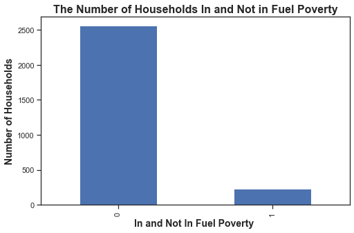

```python
fig, ax = plt.subplots()
fig.set_size_inches(8, 5)
fp["In_fuel_poverty"].value_counts().plot.bar()
ax.set_xlabel("In and Not In Fuel Poverty ",fontsize= 14,weight='bold')
ax.set_ylabel('Number of Households',fontsize= 14,weight='bold')
ax.set_title('The Number of Households In and Not in Fuel Poverty',fontsize=16,weight='bold')
plt.show()
```

#### 4.2 | Figure 2 | Fuel Poverty & Regions

The `plot_freq` function is defined for the reproducibility of the plotting of bar plot for different variables.

```python
# the plot_freq function
def plot_freq(a, xlabel, title):
    # suppress warnings
    import warnings
    warnings.filterwarnings("ignore")
    # plot
    fig, ax = plt.subplots()
    fig.set_size_inches(8, 5)
    fp_1 =fp.loc[fp["In_fuel_poverty"] == 1]   # the dataframe of households in fuel poverty
    fp_2=fp.loc[fp["In_fuel_poverty"] == 0]    # the dataframe of households not in fuel poverty
    x=list(fp[a].value_counts().to_dict().keys())
    y=list(fp[a].value_counts().to_dict().values()) # the total number of households
    y1=list(fp_1[a].value_counts().to_dict().values()) # in fuel poverty
    y2=list(fp_2[a].value_counts().to_dict().values()) # not in fuel poverty

    # fig 1
    ax.bar(x,y1, label="In Fuel Poverty")
    ax.bar(x,y2,bottom=y1, label="Not In Fuel Poverty")
    ax.set_xticklabels(x, rotation=90,fontsize= 12)
    ax.set_xlabel(xlabel,fontsize= 14,weight='bold')
    ax.set_ylabel('Number of Households',fontsize= 14,weight='bold')
    ax.set_title(f'The Distribution Households of different {title}',fontsize=16, weight='bold')
    plt.legend()

    # fig 2
    ax2=ax.twinx()
    y3 =[i*100/j for i, j in zip(y1,y)] ## the percentage of fuel poverty  in differnt
    plt.plot(x, y3)
    ax2.set_ylabel("% of Households in fuel poverty")
    plt.show()
```

```python
# the plot_box function explore the realtionship between `hh_income` or	`fuel_costs` with other variables
def plot_box(a,b,xlabel,ylabel):
    fig,ax = plt.subplots()
    fig.set_size_inches(8, 5)
    ax=sns.boxplot(x=fp[a],y=fp[b])
    ax.set_xticklabels(ax.get_xticklabels(),fontsize=12) #,rotation=45
    ax.set_xlabel(xlabel,fontsize=14,weight='bold')
    ax.set_ylabel(ylabel,fontsize=14,weight='bold')
    ax.set_title(f'{ylabel} of different {xlabel}',fontsize=16,color='black',weight='bold')
    plt.show()
```

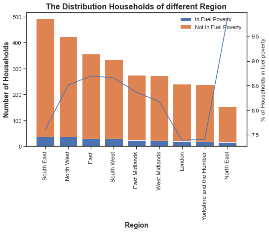

```python
plot_freq(a="Region",xlabel="Region",title="Region")
```

#### 4.2 | Figure 3 | Fuel Poverty & Tenure types

**Figure 3** shows that fuel poverty is more likely to happen in private rented dwellings while owner-occupied tensure are less likely to be in fuel poverty.

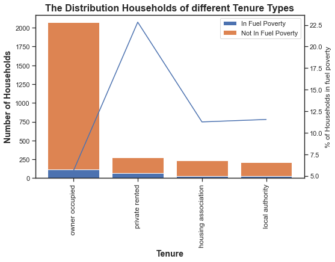

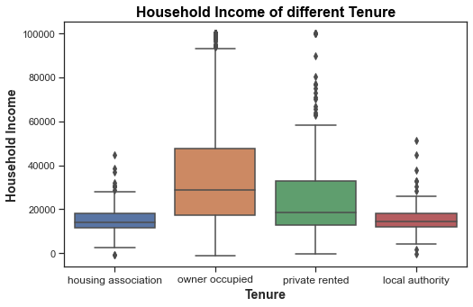

```python
plot_freq(a="Tenure",xlabel="Tenure",title="Tenure Types"),
plot_box(a="Tenure",b="hh_income",xlabel="Tenure",ylabel="Household Income",)
```

#### 4.2 | Figure 4 | Fuel poverty & Dwelling Type

We will further remove the households that are labeled as `converted and non-residential`.

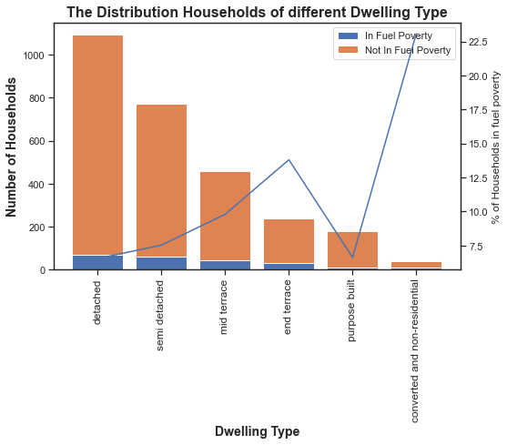

```python
plot_freq(a="DWtype",xlabel="Dwelling Type", title="Dwelling Type")
```

```python
# remove the category of the "converted and non-residential"
fp = fp.loc[fp["DWtype"] != "converted and non-residential"]
```

#### 4.2 | Figure 5 | Fuel poverty & floor area

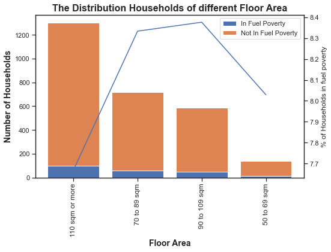

```python
plot_freq(a="FloorArea",xlabel="Floor Area",title="Floor Area")
```

#### 4.2 | Figure 6 | Fuel poverty & House Age

```python
# check the bins of age groups
fp['DWage'].unique()
```

```
array(['Post 1990', 'Pre 1850', '1945 to 1964', '1965 to 1974',
       '1981 to 1990', '1900 to 1918', '1919 to 1944', '1975 to 1980',
       '1850 to 1899'], dtype=object)
```

```python
# re-categorize the age groups
fp['DWage'].loc[fp.DWage =="Pre 1850"]="Pre 1919"
fp['DWage'].loc[fp.DWage =="1850 to 1899"]="Pre 1919"
fp['DWage'].loc[fp.DWage =="1900 to 1918"]="Pre 1919"
fp['DWage'].loc[fp.DWage =="1965 to 1974"]="1965 to 1980"
fp['DWage'].loc[fp.DWage =="1975 to 1980"]="1965 to 1980"

# re-order the levels of categories
fp['DWage']=pd.Series(pd.Categorical(fp['DWage'],
                      categories=['Pre 1919','1919 to 1944','1945 to 1964','1965 to 1980','1981 to 1990','Post 1990'],ordered=True))
```

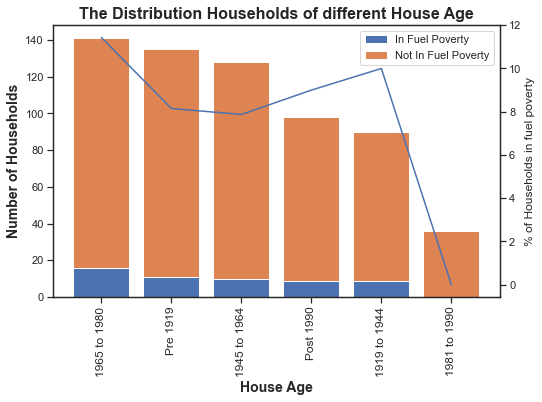

```python
plot_freq(a ="DWage",xlabel="House Age",title="House Age")
```

#### 4.2 | Figure 7| Fuel Poverty & main fuel type

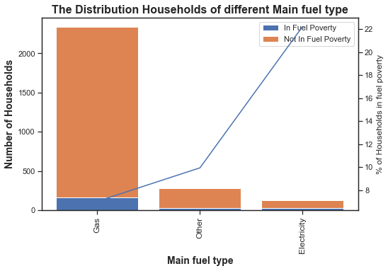

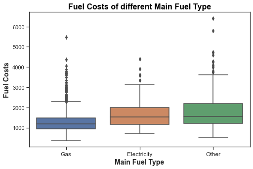

```python
plot_freq(a ="Mainfueltype",xlabel="Main fuel type",title="Main fuel type"),
plot_box(a="Mainfueltype",b="fuel_costs",xlabel="Main Fuel Type",ylabel="Fuel Costs")
```

#### 4.2 | Figure 8 | Fuel Poverty & EPC rating

`Figure 8` shows that most households have a EPC rating D and households have EPC rating F and G are more likely to be in fuel poverty.

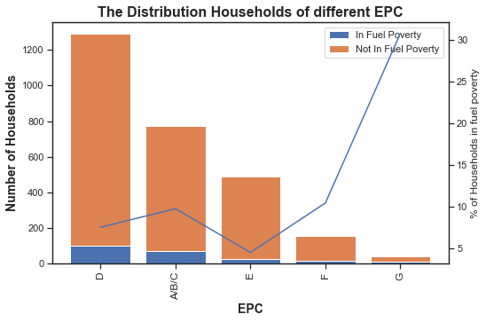

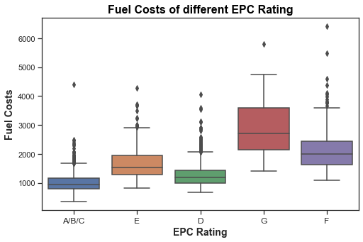

```python
plot_freq(a ="EPC",xlabel="EPC",title="EPC"),
plot_box(a="EPC",b="fuel_costs",xlabel ="EPC Rating",ylabel="Fuel Costs")
```

#### 4.2 | Figure 9 | Fuel Poverty & Household Composition & House size

`Figure 9` shows that more than 20% of households that have more than 4 people are in fuel poverty, followed by single person households.This aligns well with the report by Wales Government that in England and Wales,single person households under the age of 60 are the third highest group, with 27% and 31% respectively living in fuel poverty.

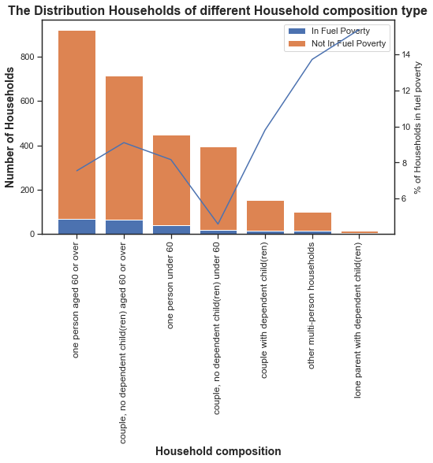

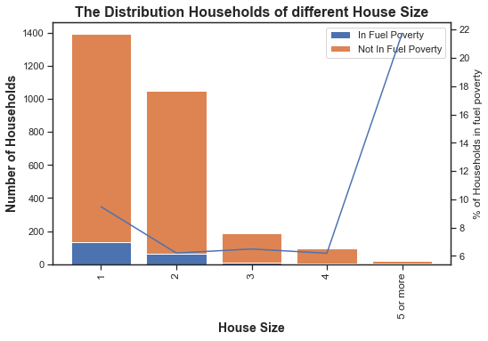

```python
plot_freq(a ="hhcompx",xlabel="Household composition",title="Household composition type"),
plot_freq(a ="hhsize",xlabel="House Size",title="House Size")
```

#### 4.2 | Figure 10 | Fuel Poverty & Working Status

`Figure 10` shows that there are 3 employment status of the Household Refrence Person (HRP) in the survey, namely, inactive (retired), working, and unemployed. Among them, 33% of households with unemployed HRP are in fuel poverty.

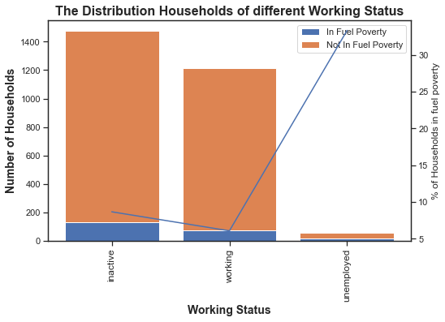

```python
plot_freq(a ="Head_Working_Status",xlabel="Working Status",title="Working Status")
```

#### 4.2 | Figure 11 | Fuel poverty & Ethics

`Figure 11` shows that non-white people are more likely to be fuel poor than white people.This is because on white people earn much more than non-white people in the UK while both of them have similar energy consumption levels. Around 13% housholds occupied by non-white people are in fuel poverty.

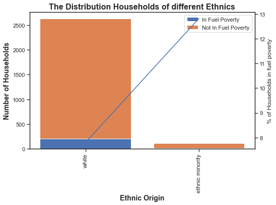

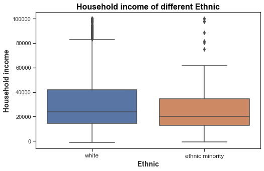

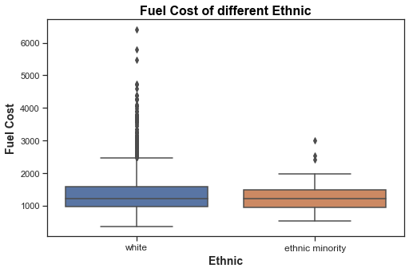

```python
plot_freq(a ="Head_Ethnic_Origin",xlabel="Ethnic Origin",title="Ethnics"),
plot_box(a="Head_Ethnic_Origin",b="hh_income",xlabel ="Ethnic",ylabel= "Household income")
plot_box(a="Head_Ethnic_Origin",b="fuel_costs",xlabel ="Ethnic",ylabel= "Fuel Cost")
```

#### 4.2 | Figure 12 | Distribution of Household Income

The distribution of household income follows a postive skewness distribution.The mean household income of our dataset is £31384. According to pension year, only households with yearly income above £8000 are retained.

```python
fp['hh_income'].describe()
```

```
count      2746.000000
mean      31384.611071
std       22938.233931
min       -1034.000000
25%       14543.500000
50%       23618.500000
75%       41673.750000
max      100000.000000
Name: hh_income, dtype: float64
```

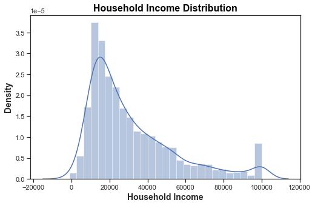

```python
fig,ax = plt.subplots()
sns.distplot(fp['hh_income'])
fig.set_size_inches(8, 5)
ax.set_xlabel("Household Income",fontsize=14,weight='bold')
ax.set_ylabel("Density",fontsize=14,weight='bold')
ax.set_title("Household Income Distribution",fontsize=16,color='black',weight='bold')
plt.show()
```

```python
# retain households that have income more than £8000/year
fp=fp.loc[fp.hh_income>=8000]
```

#### 4.2 | Figure 13 | Distribution of Fuel costs

```python
fp['fuel_costs'].describe()
```

```
count    2629.000000
mean     1367.323309
std       577.226019
min       353.500000
25%       977.530000
50%      1229.320000
75%      1581.630000
max      6414.140000
Name: fuel_costs, dtype: float64
```

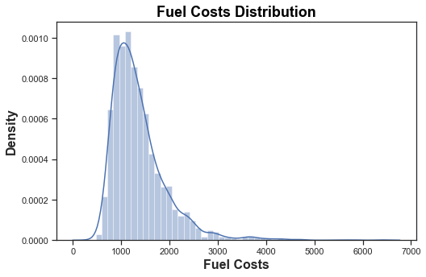

```python
fig,ax = plt.subplots()
sns.distplot(fp["fuel_costs"])
fig.set_size_inches(8, 5)
ax.set_xlabel("Fuel Costs",fontsize=16,weight='bold')
ax.set_ylabel("Density",fontsize=16,weight='bold')
ax.set_title("Fuel Costs Distribution",fontsize=18,color='black',weight='bold')
plt.show()
```

```python
# retain households have fuel costs below 5000
fp=fp.loc[fp.fuel_costs<=5000]
```

## 5. Classification Algorithms

As shown in **Figure 1**, the dataset is imbalanced, with only minority of households are in fuel poverty. However, most of the classification algorithms are designed for balanced datasets. Hence, the results of the model can have poor predictve performance for minority class while tend to be overfitting for majority class. The most common methods to mitigate this problem are downsampling and upsampling. This section will test the performance with both downsampling and upsampling techinques to compare the results. To evaluate the results, f1 score is used, which combines the precision and recall of a classifier into a single metric by taking their harmonic mean.

```python
## imbalanced dataset
fp["In_fuel_poverty"].value_counts()
```

```
0    2466
1     160
Name: In_fuel_poverty, dtype: int64
```

### 5.1 | Functions for re-sampling and train-test-split

```python
### remove the household income, household costs, and fuel costs
fp_test= fp.iloc[:,3:]
#fp_test=pd.get_dummies(fp_test)
fp_test.info()
```

```
<class 'pandas.core.frame.DataFrame'>
Int64Index: 2626 entries, 0 to 11951
Data columns (total 19 columns):
 #   Column               Non-Null Count  Dtype
---  ------               --------------  -----
 0   FullincDeciles       2626 non-null   object
 1   EPC                  2626 non-null   object
 2   Region               2626 non-null   object
 3   Ongas                2626 non-null   object
 4   Tenure               2626 non-null   object
 5   DWtype               2626 non-null   object
 6   DWage                598 non-null    category
 7   FloorArea            2626 non-null   object
 8   CentralHeating       2626 non-null   object
 9   Mainfueltype         2626 non-null   object
 10  WallType             2626 non-null   object
 11  Loftins              2626 non-null   object
 12  boiler               2626 non-null   object
 13  hhcompx              2626 non-null   object
 14  Head_Working_Status  2626 non-null   object
 15  Head_Ethnic_Origin   2626 non-null   object
 16  hhsize               2626 non-null   object
 17  hhsick               2626 non-null   object
 18  In_fuel_poverty      2626 non-null   uint8
dtypes: category(1), object(17), uint8(1)
memory usage: 374.6+ KB
```

The re-sampling and train-test split function

```python
def sampling(sample_method):
    # data split
    X=fp_test.drop(['In_fuel_poverty'],axis=1)
    X=pd.get_dummies(X)
    y=fp_test["In_fuel_poverty"]

    ## chosing method
    if sample_method =="upsampling":
        from imblearn.over_sampling import SMOTE # oversampling method
        smote = SMOTE()
        X, y = smote.fit_resample(X, y)
        print("1. Shape of New Dataset:\n",y.value_counts())
    ## downsampling
    elif sample_method =="downsampling":
        from imblearn.under_sampling import RandomUnderSampler
        rus = RandomUnderSampler(random_state=42, replacement=True) # downsampling
        X, y = rus.fit_resample(X, y)
        print("1. Shape of New Dataset:\n",y.value_counts())
    else:
        print("1.Please Check the spelling of the sampling method, the result is for the original dataset")

    # print size of the size before and after resampling
    #print("Orginal dataset:\n",fp_test["In_fuel_poverty"].value_counts())


    # dictVectorizer (modified from CASA workshop 7)
    from sklearn.feature_extraction import DictVectorizer
    vec = DictVectorizer()  # create the DictVectorizer object
    data_dict = X.to_dict('records')
    vec_array = vec.fit_transform(data_dict).toarray()  # execute process on the record dictionaries and transform the result into a numpy array object
    features =vec.get_feature_names_out()

    # split
    from sklearn.model_selection import train_test_split
    random_state_split = 101
    X_train, X_test, y_train, y_test = train_test_split(vec_array, y, random_state=random_state_split)

    #(modified from CASA workshop 7)
    X_train = np.nan_to_num(X_train)
    X_test = np.nan_to_num(X_test)
    y_train = np.nan_to_num(y_train)
    y_test = np.nan_to_num(y_test)

    print("2. The size of training and testing datasets are:",len(X_train),len(X_test))

    # return
    return X_train, X_test, y_train, y_test,features
```

### 5.2 | Functions for classification method performance

The `classification_perform` function combines the sampling function to give (1) the metrics of classifiction methods for either up or down sampling method, and (2) a plot of the feather importance.

The `class_results` function further simply `classification_perform` function to give results for a given algorithm with up and downsampling methods.

```python
## the classification_perform fucntion combines the sampling function to give (1) the metrics of classifiction methods and
# for both up and down sampling method, (2) plot the feature importance graph
def classification_perform (sample_method, algorithm):

    X_train, X_test, y_train, y_test,features=sampling(sample_method)
    # choosing the classification algorithms
    random_state = 102
    max_iter =500
    if algorithm == "MLPClassifier":
        #from sklearn.neural_network import MLPClassifier
        clf = MLPClassifier(random_state = random_state, max_iter =max_iter)
        #clf.fit(X_train, y_train)
    elif algorithm == "LogisticRegression":
        #from sklearn.linear_model import LogisticRegression
        clf = LogisticRegression(random_state = random_state,max_iter =max_iter)
        #clf.fit(X_train, y_train)
    elif algorithm == "DecisionTreeClassifier":
        #from sklearn.tree import DecisionTreeClassifier
        clf = DecisionTreeClassifier(random_state = random_state)
        #clf.fit(X_train, y_train)
    elif algorithm == "AdaBoostClassifier":
        #from sklearn.ensemble import AdaBoostClassifier
        clf = AdaBoostClassifier(random_state = random_state)
        #clf.fit(X_train, y_train)
    elif algorithm == "RandomForestClassifier":
        clf = RandomForestClassifier(random_state = random_state)
        #clf.fit(X_train, y_train)
    else:
        print("Please check the spelling of algorithm")

    clf.fit(X_train, y_train)
    #print("The results of:",algorithm)
    #print("The predicted class of the first individual: {}".format(clf.predict(X_train[0:1, :])))
    #print("The predicted probability of the first individual: {}".format(clf.predict_proba(X_train[0:1, :])))
    #print("The accuracy is:",clf.score(X_test, y_test))

    #from sklearn import metrics
    predictions = clf.predict(X_test)
    print(f'3. The performance of {algorithm}:')
    print(metrics.classification_report(y_test, predictions))

    # plot feature importance
    #f_i = list(zip(features,clf.feature_importances_))
    #f_i.sort(key = lambda x : x[1])
    #plt.rcParams['figure.figsize'] = (8.0, 18.0)
    #plt.barh([x[0] for x in f_i],[x[1] for x in f_i])
    #plt.xlabel("Feature importance")
    #plt.title("Feature importance ranking")
    #plt.show()


# this funtion can give the output of a given algorithm with both sampling methods
def class_results(algorithm):
    print("The results for Undersampling:")
    print(classification_perform(sample_method="downsampling",algorithm="algorithm"))
    print("The results for Upsampling:")
    print(classification_perform(sample_method="upsampling",algorithm="algorithm"))
```

## 6. Results and Discussion

### 6.1 | Before resampling

As this is an imblanced dataset with the household in fuel poverty (class 1) as minority, classifier that have a `highest Recall rate` and good `precision rate` for **class 1** is desired. When checking the results below, we find that the `AdaBoostClassifier` give the best preformance with f1 score = 0.44 while RandomForest has the poorest performace. The explaination of metrics.classification_report can be found [here](https://scikit-learn.org/stable/modules/model_evaluation.html#classification-report).

```python
classification_perform(sample_method='original',algorithm="MLPClassifier"),
classification_perform(sample_method='original',algorithm="LogisticRegression"),
classification_perform(sample_method='original',algorithm="AdaBoostClassifier")
```

```
1.Please Check the spelling of the sampling method, the result is for the original dataset
2. The size of training and testing datasets are: 1969 657
3. The performance of MLPClassifier:
              precision    recall  f1-score   support

           0       0.95      0.97      0.96       616
           1       0.34      0.24      0.29        41

    accuracy                           0.92       657
   macro avg       0.65      0.61      0.62       657
weighted avg       0.91      0.92      0.92       657

1.Please Check the spelling of the sampling method, the result is for the original dataset
2. The size of training and testing datasets are: 1969 657
3. The performance of LogisticRegression:
              precision    recall  f1-score   support

           0       0.95      0.99      0.97       616
           1       0.56      0.22      0.32        41

    accuracy                           0.94       657
   macro avg       0.76      0.60      0.64       657
weighted avg       0.93      0.94      0.93       657

1.Please Check the spelling of the sampling method, the result is for the original dataset
2. The size of training and testing datasets are: 1969 657
3. The performance of AdaBoostClassifier:
              precision    recall  f1-score   support

           0       0.96      0.98      0.97       616
           1       0.56      0.37      0.44        41

    accuracy                           0.94       657
   macro avg       0.76      0.67      0.71       657
weighted avg       0.93      0.94      0.94       657
```

```python
classification_perform(sample_method='original',algorithm="DecisionTreeClassifier")
classification_perform(sample_method='original',algorithm="RandomForestClassifier")
```

```
1.Please Check the spelling of the sampling method, the result is for the original dataset
2. The size of training and testing datasets are: 1969 657
3. The performance of DecisionTreeClassifier:
              precision    recall  f1-score   support

           0       0.95      0.96      0.96       616
           1       0.33      0.32      0.32        41

    accuracy                           0.92       657
   macro avg       0.64      0.64      0.64       657
weighted avg       0.92      0.92      0.92       657

1.Please Check the spelling of the sampling method, the result is for the original dataset
2. The size of training and testing datasets are: 1969 657
3. The performance of RandomForestClassifier:
              precision    recall  f1-score   support

           0       0.94      1.00      0.97       616
           1       0.60      0.07      0.13        41

    accuracy                           0.94       657
   macro avg       0.77      0.53      0.55       657
weighted avg       0.92      0.94      0.92       657
```

### 6.2 | Downsampling

In this section, the dataset is downsampled to have a balanced distribution of the two classes. After downsampling, 160 instances for the each class are obtained. For this balanced new dataset, `micro-averaging f1 scores` are compared for all the algorithms.[`micro-averaging f1 scores`](https://scikit-learn.org/stable/modules/model_evaluation.html#classification-report) calculates the mean of binary metrics, assigning equal weights to each class.

Generally,`tree-based classification methods such as decision tree and random forest algorithms show poor performance` than `MLPClassifer`,`LogisticRegression`, and `AdaBoostClassifier`.

```python
classification_perform(sample_method='downsampling',algorithm="MLPClassifier"),
classification_perform(sample_method='downsampling',algorithm="LogisticRegression"),
classification_perform(sample_method='downsampling',algorithm="AdaBoostClassifier")
```

```
1. Shape of New Dataset:
 0    160
1    160
Name: In_fuel_poverty, dtype: int64
2. The size of training and testing datasets are: 240 80
3. The performance of MLPClassifier:
              precision    recall  f1-score   support

           0       0.71      0.79      0.75        38
           1       0.79      0.71      0.75        42

    accuracy                           0.75        80
   macro avg       0.75      0.75      0.75        80
weighted avg       0.75      0.75      0.75        80

1. Shape of New Dataset:
 0    160
1    160
Name: In_fuel_poverty, dtype: int64
2. The size of training and testing datasets are: 240 80
3. The performance of LogisticRegression:
              precision    recall  f1-score   support

           0       0.70      0.84      0.76        38
           1       0.82      0.67      0.74        42

    accuracy                           0.75        80
   macro avg       0.76      0.75      0.75        80
weighted avg       0.76      0.75      0.75        80

1. Shape of New Dataset:
 0    160
1    160
Name: In_fuel_poverty, dtype: int64
2. The size of training and testing datasets are: 240 80
3. The performance of AdaBoostClassifier:
              precision    recall  f1-score   support

           0       0.72      0.76      0.74        38
           1       0.78      0.74      0.76        42

    accuracy                           0.75        80
   macro avg       0.75      0.75      0.75        80
weighted avg       0.75      0.75      0.75        80
```

The tree-based alogrithms below have poor performance and decision tree the worst.

```python
classification_perform(sample_method='downsampling',algorithm="DecisionTreeClassifier")
classification_perform(sample_method='downsampling',algorithm="RandomForestClassifier")
```

```
1. Shape of New Dataset:
 0    160
1    160
Name: In_fuel_poverty, dtype: int64
2. The size of training and testing datasets are: 240 80
3. The performance of DecisionTreeClassifier:
              precision    recall  f1-score   support

           0       0.64      0.71      0.67        38
           1       0.71      0.64      0.67        42

    accuracy                           0.68        80
   macro avg       0.68      0.68      0.67        80
weighted avg       0.68      0.68      0.68        80

1. Shape of New Dataset:
 0    160
1    160
Name: In_fuel_poverty, dtype: int64
2. The size of training and testing datasets are: 240 80
3. The performance of RandomForestClassifier:
              precision    recall  f1-score   support

           0       0.65      0.79      0.71        38
           1       0.76      0.62      0.68        42

    accuracy                           0.70        80
   macro avg       0.71      0.70      0.70        80
weighted avg       0.71      0.70      0.70        80
```

### 6.3 | Upsampling

In this section, the dataset is upsampled to have a balanced distribution of the two classes. After downsampling, **2466** instances for the each class are obtained. For this balanced new dataset, micro-averaging f1 scores are compared for all the algorithms. All the algorithms have similar and improved performance, with `Random Forest classifier` have the highest score of 0.98.

```python
classification_perform(sample_method='upsampling',algorithm="MLPClassifier"),
classification_perform(sample_method='upsampling',algorithm="LogisticRegression"),
classification_perform(sample_method='upsampling',algorithm="AdaBoostClassifier")
```

```
1. Shape of New Dataset:
 0    2466
1    2466
Name: In_fuel_poverty, dtype: int64
2. The size of training and testing datasets are: 3699 1233
3. The performance of MLPClassifier:
              precision    recall  f1-score   support

           0       0.95      0.98      0.96       621
           1       0.97      0.95      0.96       612

    accuracy                           0.96      1233
   macro avg       0.96      0.96      0.96      1233
weighted avg       0.96      0.96      0.96      1233

1. Shape of New Dataset:
 0    2466
1    2466
Name: In_fuel_poverty, dtype: int64
2. The size of training and testing datasets are: 3699 1233
3. The performance of LogisticRegression:
              precision    recall  f1-score   support

           0       0.95      0.99      0.97       621
           1       0.99      0.95      0.97       612

    accuracy                           0.97      1233
   macro avg       0.97      0.97      0.97      1233
weighted avg       0.97      0.97      0.97      1233

1. Shape of New Dataset:
 0    2466
1    2466
Name: In_fuel_poverty, dtype: int64
2. The size of training and testing datasets are: 3699 1233
3. The performance of AdaBoostClassifier:
              precision    recall  f1-score   support

           0       0.94      0.99      0.97       621
           1       0.99      0.94      0.96       612

    accuracy                           0.96      1233
   macro avg       0.97      0.96      0.96      1233
weighted avg       0.97      0.96      0.96      1233
```

```python
classification_perform(sample_method='upsampling',algorithm="RandomForestClassifier"),
classification_perform(sample_method='upsampling',algorithm="DecisionTreeClassifier")
```

```
1. Shape of New Dataset:
 0    2466
1    2466
Name: In_fuel_poverty, dtype: int64
2. The size of training and testing datasets are: 3699 1233
3. The performance of RandomForestClassifier:
              precision    recall  f1-score   support

           0       0.97      0.99      0.98       621
           1       0.99      0.97      0.98       612

    accuracy                           0.98      1233
   macro avg       0.98      0.98      0.98      1233
weighted avg       0.98      0.98      0.98      1233

1. Shape of New Dataset:
 0    2466
1    2466
Name: In_fuel_poverty, dtype: int64
2. The size of training and testing datasets are: 3699 1233
3. The performance of DecisionTreeClassifier:
              precision    recall  f1-score   support

           0       0.97      0.95      0.96       621
           1       0.95      0.97      0.96       612

    accuracy                           0.96      1233
   macro avg       0.96      0.96      0.96      1233
weighted avg       0.96      0.96      0.96      1233
```

### 6.4 | Feature importance

To better understand the importance of of each variable, [Chi-Suqare Test](https://machinelearningmastery.com/calculate-feature-importance-with-python/) is performed. `Chi-Square Test` is a simple tool to test if two variables are highly correlated or independent of each other. By implementing the test, we can know that which factors are highly correlated with fuel poverty.

```python
# the following method is
def feature_importance(sample_method):
    X_train, X_test, y_train, y_test,features=sampling(sample_method=sample_method)
    fs = SelectKBest(score_func=chi2, k='all') # SelectKBest is used to do feature selection.
    fs.fit(X_train, y_train)
    X_train_fs = fs.transform(X_train)
    X_test_fs = fs.transform(X_test)
    feature_dict ={'variables': features,"importance":fs.scores_}
    feature_df=pd.DataFrame(feature_dict)
    feature_df=feature_df.sort_values(by ='importance', ascending = False).reset_index(drop=True)

    # plot the feature importance
    plt.rcParams['figure.figsize'] = (20.0, 8.0)
    ## only plot the first 20 variables
    plt.bar(feature_df.iloc[:20,:]['variables'], feature_df.iloc[:20,:]['importance'])
    plt.xticks(rotation=45, ha='right',fontsize=14)
    plt.xlabel("Variables",fontsize=20,weight="bold")
    plt.ylabel("Feature importance",fontsize=20,weight="bold")
    plt.title('Feature Importance Plot',fontsize=20,weight="bold")
    plt.show()
    return feature_df
```

#### 6.4 | Figure 14 | Feature importance Graph

The results shows that households that are most likely to be in fuel poverty has the following characteristics: `income deciles, in privated rented places, without 'central heating' or 'Storage heater' system, using electricity as main fuel, and having a low EPC rating.` These results align well with the results in Section 4. Therefore, when conducting surveys for fuel poverty or social equity study, the above-mentioned factors have the highest priority.

```
1.Please Check the spelling of the sampling method, the result is for the original dataset
2. The size of training and testing datasets are: 1969 657
```

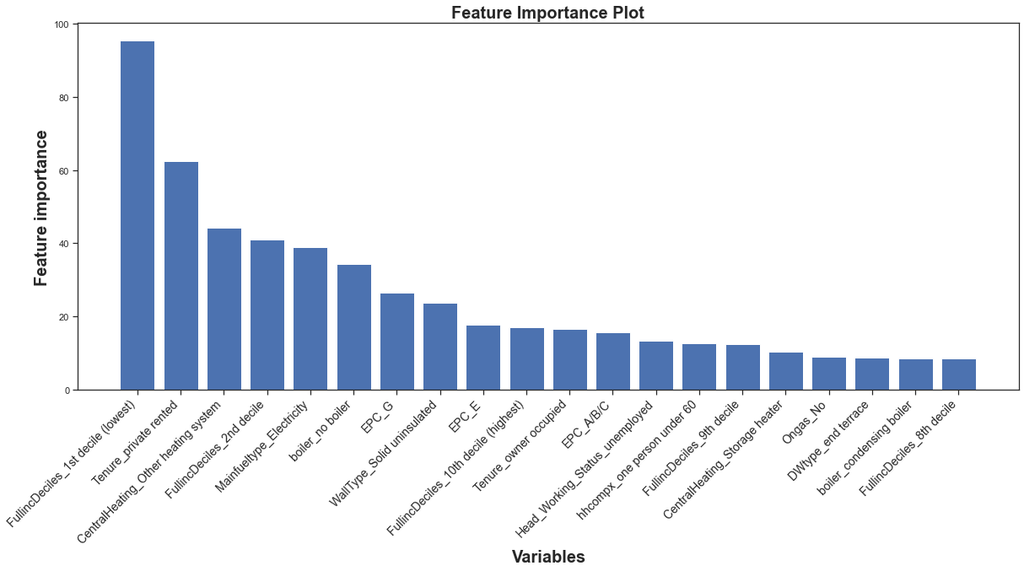

|  | variables | importance |
| --- | --- | --- |
| 0 | FullincDeciles_1st decile (lowest) | 95.382422 |
| 1 | Tenure_private rented | 62.386968 |
| 2 | CentralHeating_Other heating system | 44.341359 |
| 3 | FullincDeciles_2nd decile | 41.052799 |
| 4 | Mainfueltype_Electricity | 39.010893 |
| 5 | boiler_no boiler | 34.301631 |
| 6 | EPC_G | 26.451076 |
| 7 | WallType_Solid uninsulated | 23.798892 |
| 8 | EPC_E | 17.809320 |
| 9 | FullincDeciles_10th decile (highest) | 16.981622 |
| 10 | Tenure_owner occupied | 16.600098 |
| 11 | EPC_A/B/C | 15.722352 |
| 12 | Head_Working_Status_unemployed | 13.284369 |
| 13 | hhcompx_one person under 60 | 12.800314 |
| 14 | FullincDeciles_9th decile | 12.543243 |
| 15 | CentralHeating_Storage heater | 10.431355 |
| 16 | Ongas_No | 9.011479 |
| 17 | DWtype_end terrace | 8.869535 |
| 18 | boiler_condensing boiler | 8.562735 |
| 19 | FullincDeciles_8th decile | 8.527922 |
| 20 | WallType_Cavity with insulation | 7.211110 |
| 21 | Head_Ethnic_Origin_ethnic minority | 7.018562 |
| 22 | Region_London | 6.721169 |
| 23 | hhcompx_couple, no dependent child(ren) under 60 | 6.513407 |
| 24 | Tenure_housing association | 6.049640 |
| 25 | DWtype_detached | 5.561756 |
| 26 | FullincDeciles_7th decile | 5.312022 |
| 27 | hhsick_Yes | 4.468209 |
| 28 | hhcompx_other multi-person households | 3.743606 |
| 29 | Loftins_Not applicable | 2.991718 |

[output cut: 54 more lines]

```python
feature_importance(sample_method="original")
```

## 7. Conclusion and Limitations

**Conclusion**  
This study carried out classification of the UK fuel poverty dataset in 2015 using 5 poluar classification algorithms,with the aim of answering the following questions:

`Q1. Which classification method have the best performance for fuel poverty prediction?`

`Q2. Which fatcors are most related to fuel poverty?`

**Q1**: Randomforest classifier peroforms better with upsampling technique while other classifiers also show good performance.

**RQ2**: Income deciles, tenure type, main fuel type, whether have boiler or not, type of central heating system, EPC rating are most related to fuel poverty classification while region, floor area, dwelling age are not prominent to fuel poverty.

**Limitations and fuel poverty**  
No hyperparameter tuning was applied to the classifiers. It would be interesting to explore the fuel poverty datasets of last year and this year because of the reduction of income and the soaring fuel price and high inflation rate would drive many more household into fuel poverty. Under current curcumstances, it would be necessary to increase the energy efficiency of the dwelling or buy domestic solar PV panels.

## Bibliography

Chandra Sen, P., Hajra, M. and Ghosh, M. (2020) Supervised Classification Algorithms in Machine Learning: A Survey and Review. In: Mandal J., Bhattacharya D. (eds) Emerging Technology in Modelling and Graphics. Advances in Intelligent Systems and Computing, Springer, Singapore. Springer Singapore. doi: 10.1007/978-981-13-7403-6.

Fizaine, F., & Kahouli, S. (2019). On the power of indicators: How the choice of fuel poverty indicator affects the iden- tification of the target population. Applied Economics, 51(11), 1081–1110. https:// doi. org/ 10. 1080/ 00036 846. 2018. 15249 75

Hills, J. (2011). Fuel poverty: The problem and its measure- ment. Interim report of the of the fuel poverty review. Available on line: http:// stice rd. lse. ac. uk/ dps/ case/ cr/ CASEr eport 69. pdf

Hills J. (2012). Getting the measure of fuel poverty. Final report of the fuel poverty review. CASE report. https:// www. gov. uk/ gover nment/ uploa ds/ system/ uploa ds/ attac hment_ data/ file/ 48299/ 4664- exec- summa ry- fuel- pov- final- rpt. pdf

Kumar, R. and Verma, D. (2012) ‘Classification Algorithms for Data Mining: A Survey’, International Journal of Innovations in Engineering …, 1(2), pp. 7–14. Available at: http://citeseerx.ist.psu.edu/viewdoc/download?doi=10.1.1.305.2167&rep=rep1&type=pdf.

Lyra, K., Mirasgedis, S. and Tourkolias, C. (2022) ‘From measuring fuel poverty to identification of fuel poor households: a case study in Greece’, Energy Efficiency. Springer Netherlands, 15(1). doi: 10.1007/s12053-021-10017-6.

Mashhoodi, B., Stead, D., & van Timmeren, A. (2019). Spa- tial homogeneity and heterogeneity of energy poverty: A neglected dimension. Annals of GIS, 25, 19–31. https:// doi. org/ 10. 1080/ 19475 683. 2018. 15572 53

Tyszler, J. and Leseur, A. (2013) ‘Combating Fuel Poverty : Policies in’, (41), pp. 1–42.